# Creux_26-4-17

### 3.2.4 Exercises

1. Run ggplot(data=mpg)  
   I don’t see anything
2. There are 234 rows and 11 columns
3. The drv variable discribes the type of drive for the car, front wheel or four wheel drive
4. Scatter plot of hwy vs cyl

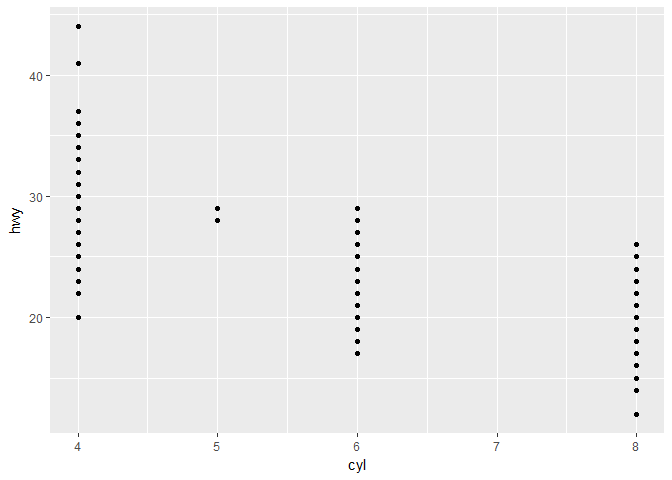

5.

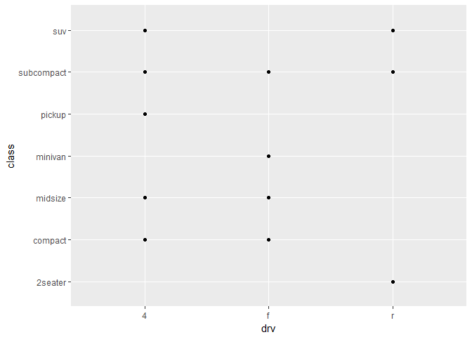

```r
 ggplot(data=mpg) + geom_point(mapping = aes(x=drv, y=class))
```

This plot is not useful because this does not give information about how many cars are in category for each class

### 3.3.1 Exercises

1. The second last bracket is in the wrong place it should read: ggplot(data=mpg) + geom_point(mapping = aes(x=displ, y=hwy), color=“blue”)

2.continuous - hwy, cty, displ, year, cyl; Categorical - manufacturer model, trans, drv, fl, class

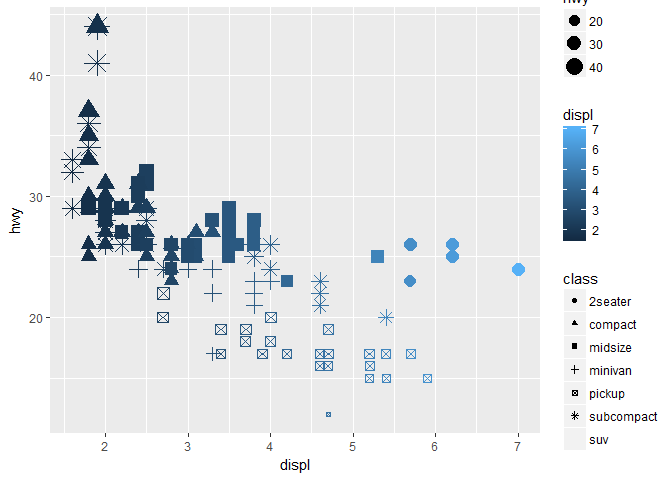

```r
ggplot(data=mpg) + geom_point(mapping = aes(x=displ, y=hwy, color= displ, size=hwy, shape=class))
```

Yes, Shape cannot be used with continuous data

4. you can quickly see trends
5. Use the stroke aesthetic to modify the width of the border in shapes that have a border like shape 21
6. It colors everything in dipl lower than 5 one color and everything higher than 5 another color and marks the lower than five set as true and the higher than five set as false

### 3.5.1 Exercises

1. Faceting a continuous variable leads to it being broken into discrete values
2. The empty cells mean that there were no cars that had that number of cylinders in that specific drive category, they are the missing data points on the ggplot(data=mpg) + geom_point(mapping = aes(x=drv, y=cyl)) plot

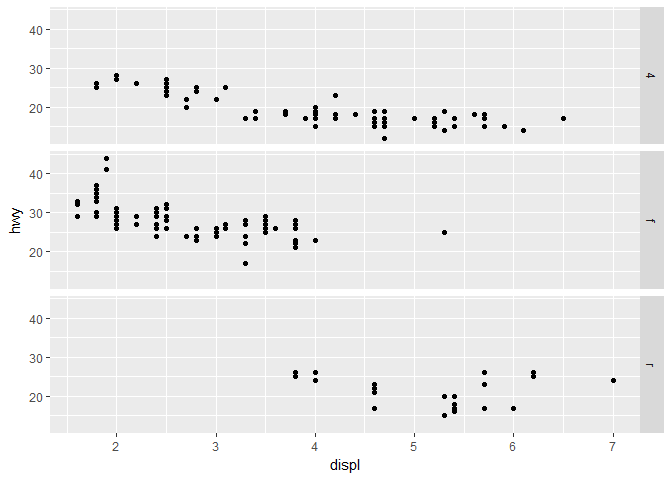

```r
ggplot(data = mpg) +
  geom_point(mapping = aes(x = displ, y = hwy)) +
  facet_grid(drv ~ .)
```

And

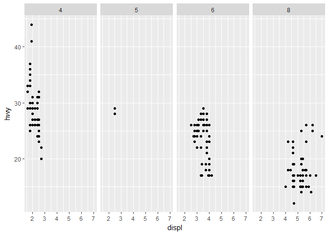

```r
ggplot(data = mpg) +
  geom_point(mapping = aes(x = displ, y = hwy)) +
  facet_grid(. ~ cyl)
```

using this code the facets the data accourding to the descrete category listed the . is a place holder so that you only facet by a single variable and not for both columns and rows.

4. The advantages of faceting is that you can clearly look at the hwy and displ for each class of car to see how they perfom in a single graph.In a larger dataset in may produce too many facets and it may become difficult to quickly asses the different classes and then a color graph might be easier to quickly see the differences.
5. nrow allows the user to control the number of rows in the facet and ncol the number of columns. other options controlling the layout of individual panels includes; scales, shrink, labeller, as.table, swtich, drop, dir, strip.position. Facet_grid does not specify rows or columns because you are faceting according to the discrete categories in the data and these will dictate the number of rows or columns
6. you should always put the variable with more unique levels in the column place because it fits better